# Práctica Regresión avanzada

Alvaro Herreruela

10/2/2021

## Introducción

Durante este último año hemos escuchado mucho ruido alrededor del mismo tema, el Covid. Los países se han quedado paralizados ante la presencia de un virus que en principio parecía inofensivo y luego resulta que ha dejado miles de muertos, dejando a los gobiernos destapados y sus decisiones en entredicho. Prácticamente todos los países han maniobrado de la misma manera a la hora de afrontar el problema. Compra de recursos como mascarillas y tests, y cierre total y parcial de territorios.

Muchas personas se han preguntado si las medidas han sido las adecuadas o incluso si han sido efectivas para afrontar esta crisis. Es por eso, que he decidido analizar el impacto de los recursos utilizados (hospitales y PCR) y de las medidas de movilidad impuestas a través de la modelos de regresión avanzada y GLM.

## Preprocesamiento

Para realizar el estudio he decidido utilizar dos datasets:

1. Covid por provincias: aquí se recogen datos sobre los recursos así com PCR, personas hospitalizadas y otros tests, todos los días desde febrero de 2020 en España por provincias y comunidades.
2. Movilidad por provincias: aquí se recoge la movilidad en super mercados, parques, farmacias, centros comerciales… todos los días desde febrero por países y territorios detro de un país

El preprocesamiento de datos ha sido algo tediosos ya que el primer dataset estaba lleno de missing values, valores incorrectos como muertes con signo negativo, outliers y muchas variables correladas. Para reducir la presencia de missing values, procedentes la gran mayoría de la falta de información de la primera ola, he filtrado por fecha a apartir del 1 de julio de 2020. He hecho esto con ambos datasets. Además he cogido el primer dataset(covid_provincias) y le he quitado posible variables correladas como por ejemplo aquellas variables acumuladas de otras variables, variables que eran la media de otras y tasas, como por ejemplo la tasa por 100.000 habitantes. Además he sustituido los valores negativos del primer dataset por 0 ya que los valores negativos no tenían sentido en el conjunto de datos.

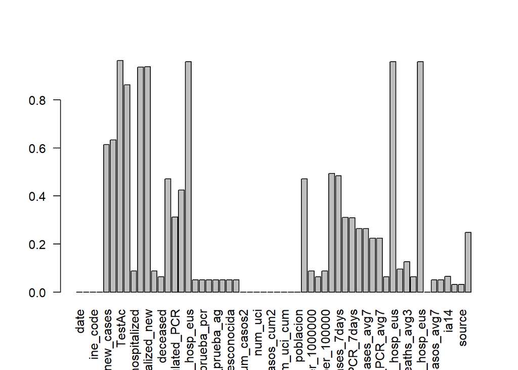

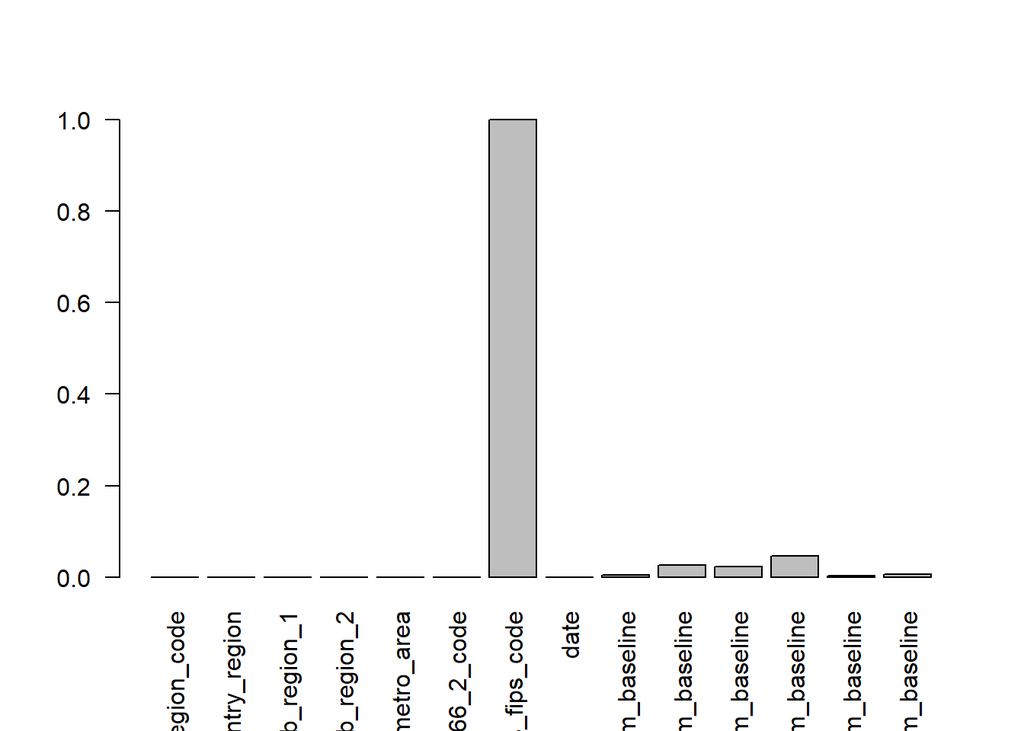

# Missing Values

Podemos observar que seguimos teniendo una gran cantidad de missing values en nuestros datasets. Para poder llegar a alguna conclusión en las hipótesis que hemos planteado hay que imputar estos missing values de alguna manera. En el primer dataset los datos faltantes son NMAR (not missing at random) lo que quiere decir que las variables dependen de ellas mismas y del conjunto de variables del dataset. En el segundo dataset los missing values son MAR (missing at random) donde los valores valtantes dependen de las observaciones de las propias variables

Para imputar los missing values, he utilizado la libreria MICE. En el primer dataset he utilizado un árbol de regresión para predecir los missing values. En este caso es necesario sacar las variables que más adelante se van a predecir del dataser para que las variables imputadas no estén influenciadas por esta variable. En el segundo caso he utilizado predictive mean machine, donde te predice según los valores observados de la propia variable.

# Reagrupación y fusión de datasets

En este último paso del feature engineering he agrupado las variables de ambos datasets por comunidades autónomas y he tenido que cambiar el nombre de todas las comunidades autónomas del segundo dataset para facilitar más adelante la fusión de ambos datasets. Por último he graficado la correlación entre las diferentes variables para echar un último vistazo a la colinealidad de las variables. He observado que new cases estaba correlada con el número de casos y hospitalize estaban correladas con varias variables. He eliminado estas variables para mi modelo GLM y así mejorar la representatividad de nuestra predicción.

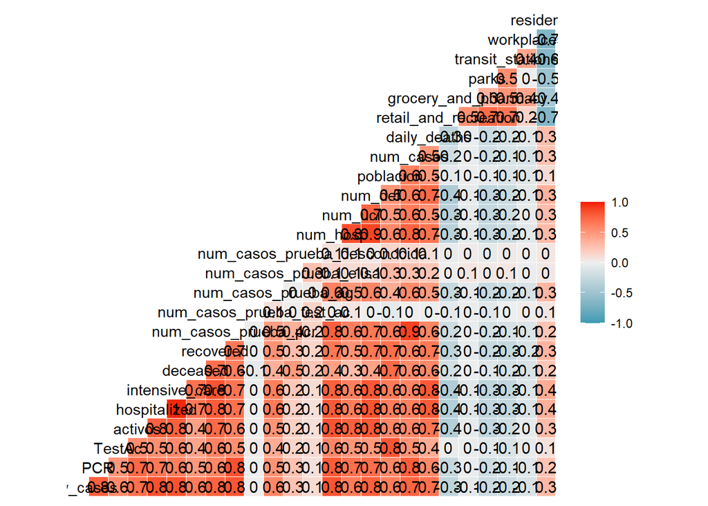

```
##      ccaa               date                PCR            activos
##  Length:4167        Length:4167        Min.   :   0.0   Min.   :    0
##  Class :character   Class :character   1st Qu.:  74.0   1st Qu.: 1044
##  Mode  :character   Mode  :character   Median : 247.0   Median : 4094
##                                        Mean   : 497.9   Mean   : 6735
##                                        3rd Qu.: 599.5   3rd Qu.: 9393
##                                        Max.   :6679.0   Max.   :78533
##   hospitalized       deceased         recovered      num_casos_prueba_pcr
##  Min.   :   0.0   Min.   :    2.0   Min.   :   125   Min.   :   0.0
##  1st Qu.:  58.0   1st Qu.:  344.5   1st Qu.:  4612   1st Qu.:  67.0
##  Median : 252.0   Median :  887.0   Median : 17560   Median : 214.0
##  Mean   : 522.8   Mean   : 2611.4   Mean   : 35420   Mean   : 491.4
##  3rd Qu.: 588.0   3rd Qu.: 2888.5   3rd Qu.: 45970   3rd Qu.: 569.0
##  Max.   :5136.0   Max.   :19716.0   Max.   :285059   Max.   :7348.0
##    poblacion         num_casos       daily_deaths     retail_and_recreation
##  Min.   :  84777   Min.   :   0.0   Min.   :  0.000   Min.   :-84.00
##  1st Qu.: 654214   1st Qu.:  51.0   1st Qu.:  0.000   1st Qu.:-37.00
##  Median :1493898   Median : 216.0   Median :  2.000   Median :-25.00
##  Mean   :2482518   Mean   : 557.3   Mean   :  9.689   Mean   :-25.98
##  3rd Qu.:2699499   3rd Qu.: 611.5   3rd Qu.: 10.000   3rd Qu.:-14.00
##  Max.   :8414240   Max.   :6998.0   Max.   :137.000   Max.   : 56.00
##  grocery_and_pharmacy     parks        transit_stations   workplaces
##  Min.   :-88.000      Min.   :-73.00   Min.   :-85.00   Min.   :-86.00
##  1st Qu.: -8.500      1st Qu.:-19.25   1st Qu.:-34.00   1st Qu.:-28.68
##  Median : -1.000      Median :  1.00   Median :-24.00   Median :-21.00
##  Mean   : -2.004      Mean   : 17.89   Mean   :-24.43   Mean   :-21.59
##  3rd Qu.:  5.000      3rd Qu.: 37.00   3rd Qu.:-15.00   3rd Qu.:-13.00
##  Max.   :131.000      Max.   :543.00   Max.   : 33.00   Max.   : 25.00
##   residential
##  Min.   :-7.250
##  1st Qu.: 3.500
##  Median : 6.000
##  Mean   : 6.613
##  3rd Qu.: 9.250
##  Max.   :31.000
```

## Distribución de las variables

Para conocer la distribución de nuestra variable a predecir he hecho un histograma. Observando el histograma vemos que la variable 0 es la más repetida. Esto nos da un primer indicio de que esta variable puede ser un 0 inflado. Podemos observar que es descendente indicándonos que los datos estan sesgados a los valores más bajos

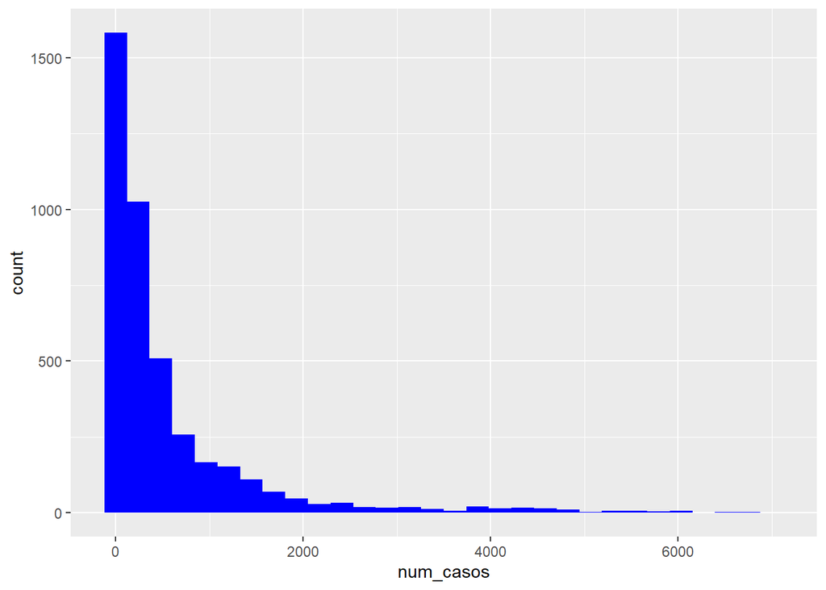

En este gráfico de barras, podemos observar que aquellas comunidades con mayor número de casos son la Comunidad de Madrid, Cataluña, Comunidad Valenciana y Andalucía

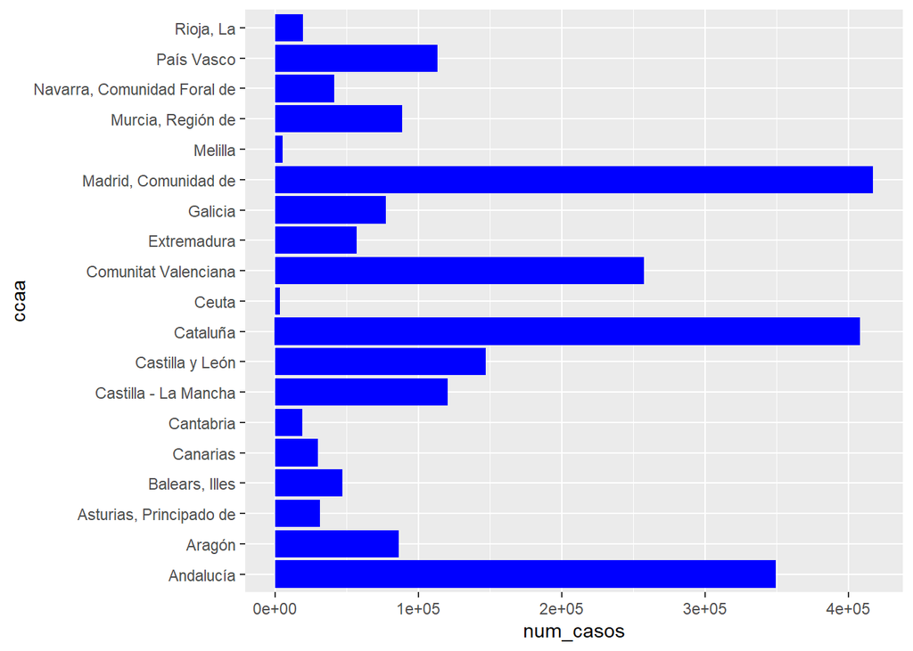

En este primer gráfico, podemos observar que no hay una aparente relacion lienal entre muerte y número de casos, lo que es un poco raro ya que normalmente cuanto más casos haya, más muertes habrá

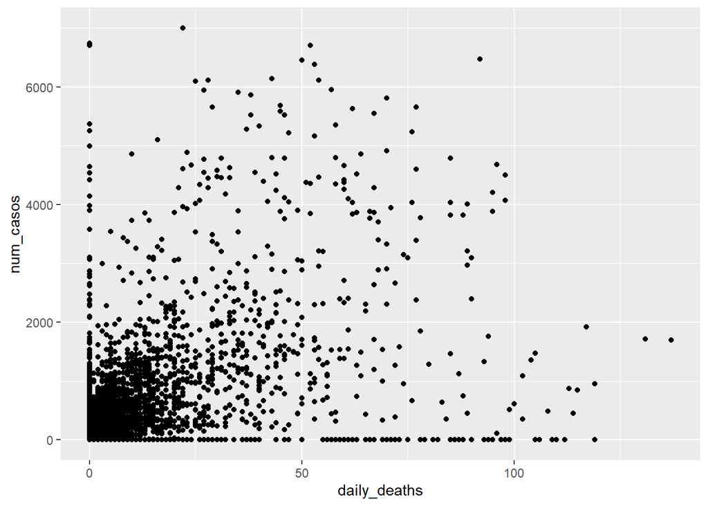

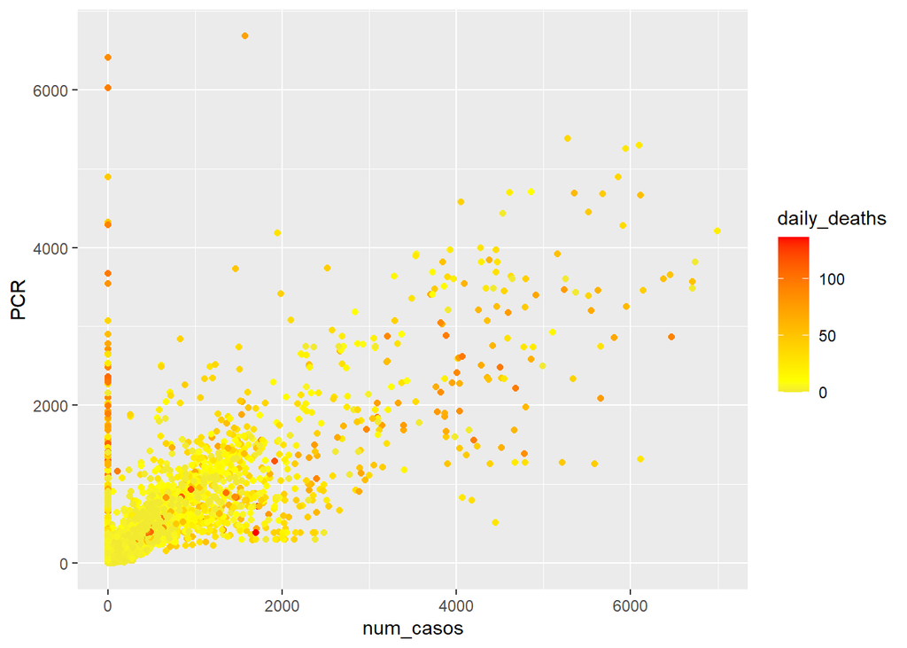

En estos dos últimos gráficos, podemos observar que no hay una relación lineal aparente entre la movilidad y el números de casos

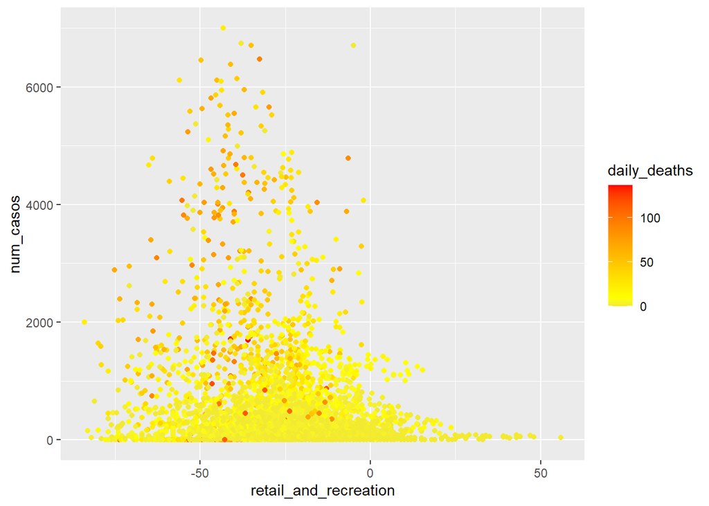

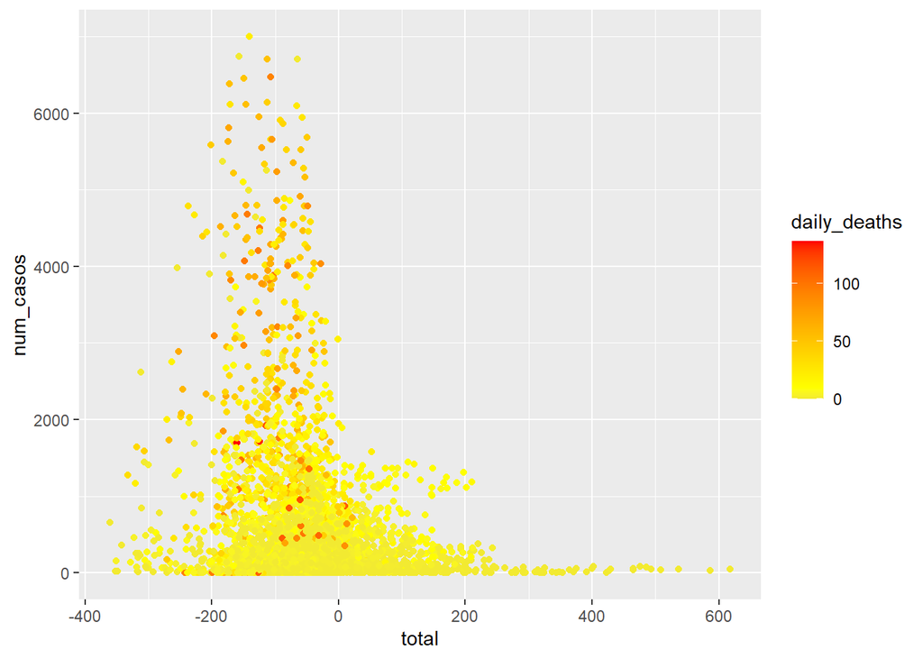

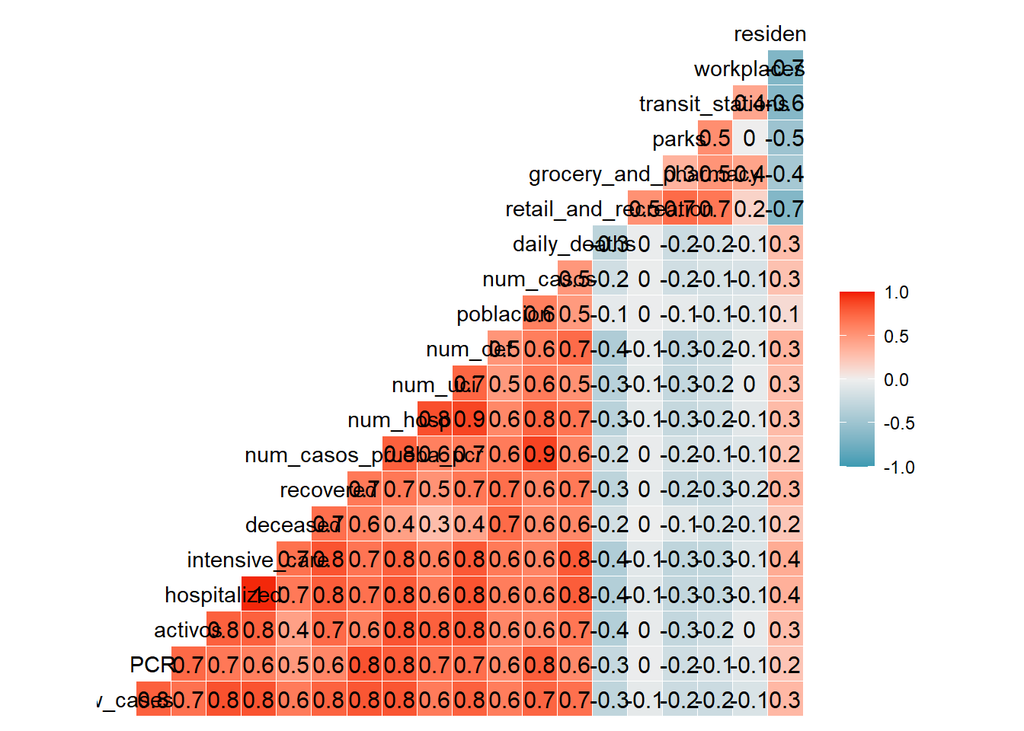

# Modelización GLM

Para modelizar, he creado una serie de bucles donde me imputa la familia y me devuelve el resumen del modelo de cada familia. Vamos a utilizar la familia gaussiana, la poisson y quasipoisson de manera que cada link por defecto es identity, log y log respectivamente. No podemos utilizar otras familias como por ejemplo la binomial, ya que la variable respuesta no es binomial.

```
## [1] "Familia: gaussian"
##
## Call:
## glm(formula = daily_deaths ~ PCR + hospitalized * recovered +
##     hospitalized * deceased, family = x, data = training)
##
## Deviance Residuals:
##     Min       1Q   Median       3Q      Max
## -68.963   -2.819   -0.315    1.232  106.988
##
## Coefficients:
##                          Estimate Std. Error t value Pr(>|t|)
## (Intercept)            -2.656e-01  2.840e-01  -0.935 0.349745
## PCR                     1.465e-03  4.084e-04   3.587 0.000339 ***
## hospitalized            1.408e-02  7.165e-04  19.654  < 2e-16 ***
## recovered              -2.431e-05  9.437e-06  -2.576 0.010030 *
## deceased                8.866e-04  1.056e-04   8.398  < 2e-16 ***
## hospitalized:recovered  2.277e-08  4.005e-09   5.686 1.42e-08 ***
## hospitalized:deceased  -2.448e-07  6.200e-08  -3.948 8.05e-05 ***
## ---
## Signif. codes:  0 '***' 0.001 '**' 0.01 '*' 0.05 '.' 0.1 ' ' 1
##
## (Dispersion parameter for gaussian family taken to be 112.7361)
##
##     Null deviance: 1043803  on 3334  degrees of freedom
## Residual deviance:  375186  on 3328  degrees of freedom
## AIC: 25231
##
## Number of Fisher Scoring iterations: 2
##
## [1] "-----------"
## [1] "Familia: poisson"
##
## Call:
## glm(formula = daily_deaths ~ PCR + hospitalized * recovered +
##     hospitalized * deceased, family = x, data = training)
##
## Deviance Residuals:
##      Min        1Q    Median        3Q       Max
## -11.4747   -2.2452   -1.2404    0.6978   21.5428
```

[output cut: 38 more lines]

```
## deceased                1.139e-04  7.655e-06  14.877   <2e-16 ***
## hospitalized:recovered -2.646e-09  2.338e-10 -11.314   <2e-16 ***
## hospitalized:deceased  -4.554e-08  3.409e-09 -13.360   <2e-16 ***
## ---
## Signif. codes:  0 '***' 0.001 '**' 0.01 '*' 0.05 '.' 0.1 ' ' 1
##
## (Dispersion parameter for quasipoisson family taken to be 11.10508)
##
##     Null deviance: 71492  on 3334  degrees of freedom
## Residual deviance: 27699  on 3328  degrees of freedom
## AIC: NA
##
## Number of Fisher Scoring iterations: 6
##
## [1] "-----------"
```

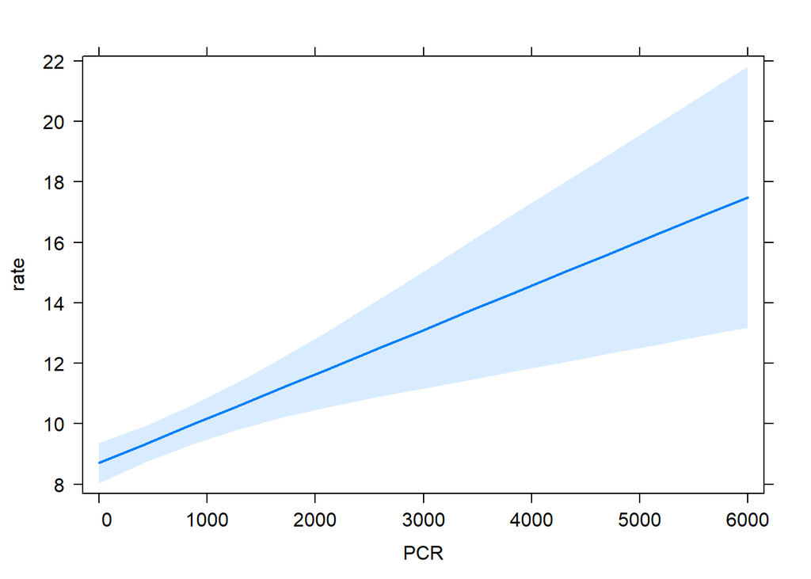

```
## NOTE: hospitalized is not a high-order term in the model
```

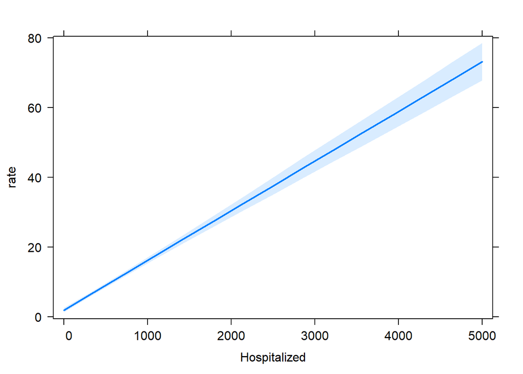

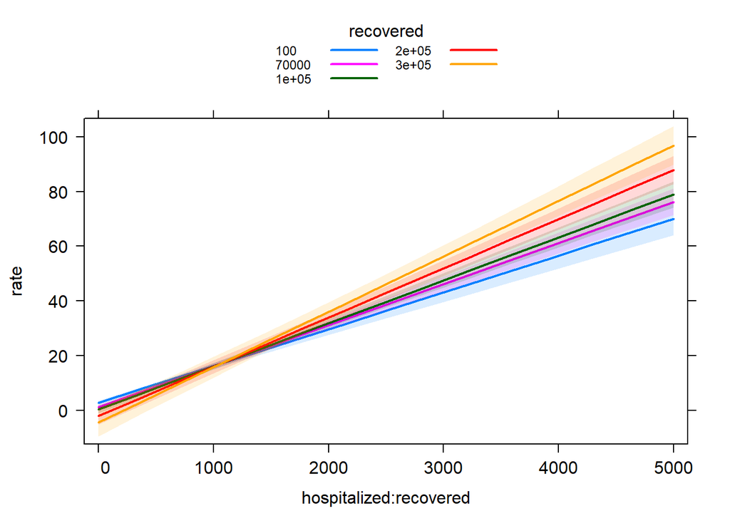

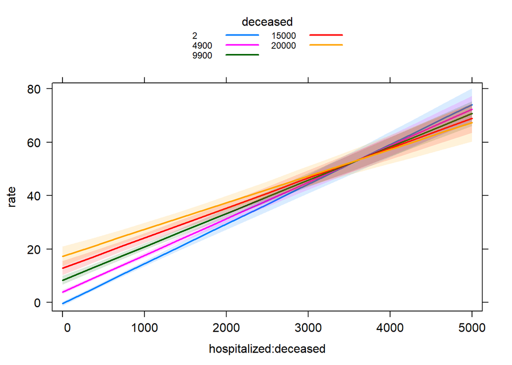

En este segundo apartado, vamos a analizar si la movilidad ha influido en el número de casos. Además antes de hacer la partición he creado una nueva variable denominada total_mov que recoge el total de movilidad de todas las areas. Para hacer la partición tomado otro training y test set con el output de número de casos en vez de muertes diarias.

```
## [1] "Familia: gaussian"
##
## Call:
## glm(formula = num_casos ~ retail_and_recreation + grocery_and_pharmacy +
##     parks + transit_stations + workplaces + residential, family = x,
##     data = training2)
##
## Deviance Residuals:
##     Min       1Q   Median       3Q      Max
## -1194.4   -479.3   -222.0    137.9   6248.6
##
## Coefficients:
##                       Estimate Std. Error t value Pr(>|t|)
## (Intercept)            286.400     48.798   5.869 4.81e-09 ***
## retail_and_recreation   -2.576      1.675  -1.538   0.1242
## grocery_and_pharmacy     6.546      1.143   5.725 1.12e-08 ***
## parks                   -1.679      0.399  -4.209 2.63e-05 ***
## transit_stations         3.814      1.514   2.519   0.0118 *
## workplaces              -2.218      1.756  -1.263   0.2066
## residential             42.967      6.664   6.447 1.30e-10 ***
## ---
## Signif. codes:  0 '***' 0.001 '**' 0.01 '*' 0.05 '.' 0.1 ' ' 1
##
## (Dispersion parameter for gaussian family taken to be 768202.3)
##
##     Null deviance: 2781079392  on 3334  degrees of freedom
## Residual deviance: 2556577175  on 3328  degrees of freedom
## AIC: 54669
##
## Number of Fisher Scoring iterations: 2
##
## [1] "-----------"
## [1] "Familia: poisson"
##
## Call:
## glm(formula = num_casos ~ retail_and_recreation + grocery_and_pharmacy +
##     parks + transit_stations + workplaces + residential, family = x,
##     data = training2)
##
## Deviance Residuals:
```

[output cut: 41 more lines]

```
## transit_stations       0.0091211  0.0025669   3.553 0.000386 ***
## workplaces            -0.0044987  0.0029565  -1.522 0.128199
## residential            0.0722530  0.0116603   6.196 6.48e-10 ***
## ---
## Signif. codes:  0 '***' 0.001 '**' 0.01 '*' 0.05 '.' 0.1 ' ' 1
##
## (Dispersion parameter for quasipoisson family taken to be 1137.858)
##
##     Null deviance: 3173349  on 3334  degrees of freedom
## Residual deviance: 2754043  on 3328  degrees of freedom
## AIC: NA
##
## Number of Fisher Scoring iterations: 6
##
## [1] "-----------"
```

```
## [1] "Familia: gaussian"
##
## Call:
## glm(formula = num_casos ~ total_mov, family = x, data = training2)
##
## Deviance Residuals:
##     Min       1Q   Median       3Q      Max
## -1073.7   -488.7   -271.1    116.1   6285.0
##
## Coefficients:
##             Estimate Std. Error t value Pr(>|t|)
## (Intercept) 460.0573    17.5101   26.27   <2e-16 ***
## total_mov    -1.8001     0.1638  -10.99   <2e-16 ***
## ---
## Signif. codes:  0 '***' 0.001 '**' 0.01 '*' 0.05 '.' 0.1 ' ' 1
##
## (Dispersion parameter for gaussian family taken to be 805244.2)
##
##     Null deviance: 2781079392  on 3334  degrees of freedom
## Residual deviance: 2683878961  on 3333  degrees of freedom
## AIC: 54821
##
## Number of Fisher Scoring iterations: 2
##
## [1] "-----------"
## [1] "Familia: poisson"
##
## Call:
## glm(formula = num_casos ~ total_mov, family = x, data = training2)
##
## Deviance Residuals:
##     Min       1Q   Median       3Q      Max
## -54.681  -25.970  -14.286    4.744  145.758
##
## Coefficients:
##               Estimate Std. Error z value Pr(>|z|)
## (Intercept)  6.067e+00  1.004e-03  6041.8   <2e-16 ***
## total_mov   -3.728e-03  8.629e-06  -432.1   <2e-16 ***
## ---
## Signif. codes:  0 '***' 0.001 '**' 0.01 '*' 0.05 '.' 0.1 ' ' 1
```

[output cut: 20 more lines]

```
##               Estimate Std. Error t value Pr(>|t|)
## (Intercept)  6.0670938  0.0363692  166.82   <2e-16 ***
## total_mov   -0.0037282  0.0003125  -11.93   <2e-16 ***
## ---
## Signif. codes:  0 '***' 0.001 '**' 0.01 '*' 0.05 '.' 0.1 ' ' 1
##
## (Dispersion parameter for quasipoisson family taken to be 1311.726)
##
##     Null deviance: 3173349  on 3334  degrees of freedom
## Residual deviance: 2978850  on 3333  degrees of freedom
## AIC: NA
##
## Number of Fisher Scoring iterations: 6
##
## [1] "-----------"
```

Graficando el modelo sobre las variables, podemos encontrar interpretaciones bastante curiosas. He graficado únicamente aquellas variables que tenian betas influyentes. Aquí podemos encontrar que a medida que aumenta la movilidad de los parques sobre la línea base, el número de casos desciende aunque podemos observar que la parte sombreada es muy ancha indicando que el intervalo de confianza es muy grande. En cambio la movilidad a farmacias, tiendas y residencias hace que el número de casos aumente. Esto se puede interpretar de manera que aquellas personas que van a las farmacias es porque están enfermas y en época de Covid, muchas de ellas pueden estar contagiadas y acuden a la farmacia sin concocimiento de ello. Los parques en cambio, a medida que han ido aumentando los casos se han ido cerrando lo que hace que el transito de personas sea menor, por eso no tiene sentido que disminuyan los casos cuando aumenta el tránsito de personas.

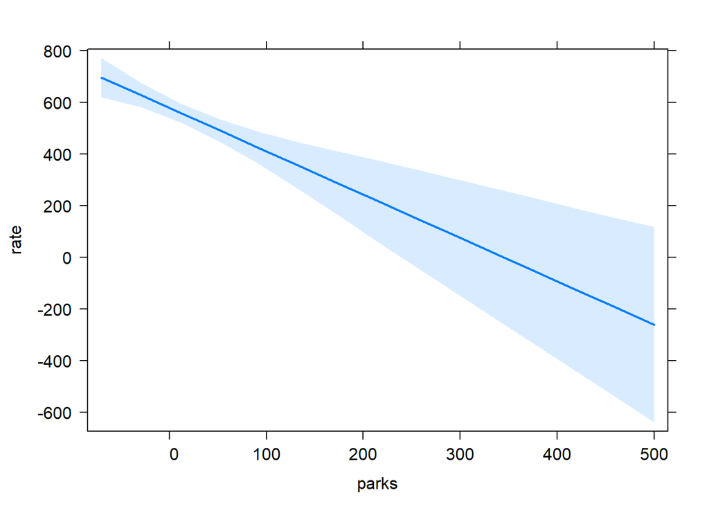

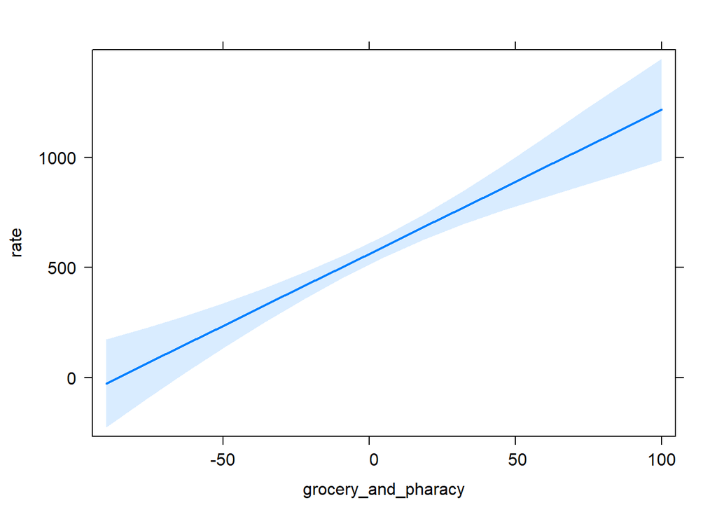

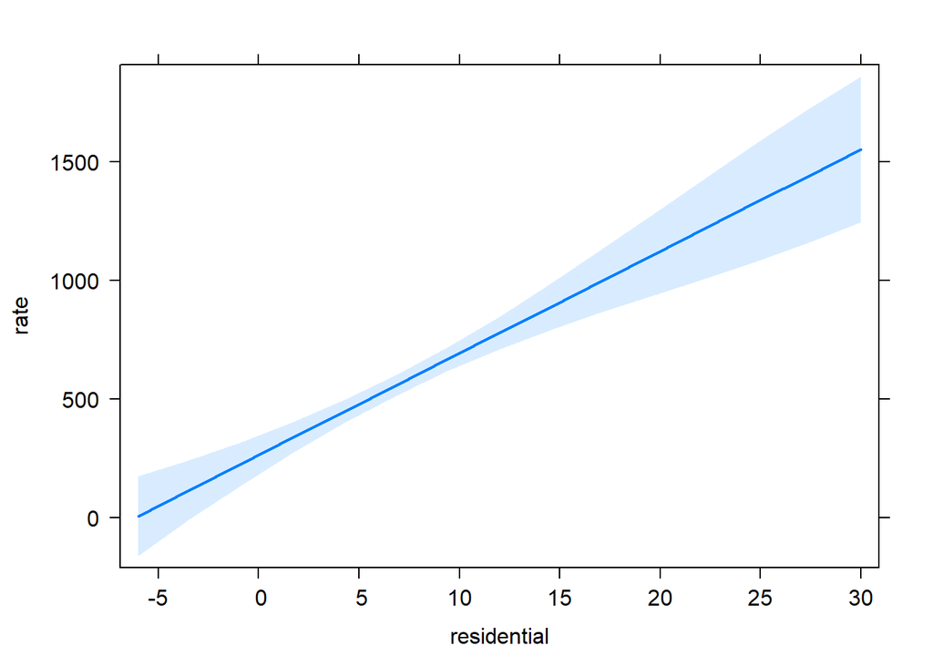

Como hemos analizado antes, ambas variables respuesta tienden a tener muchos ceros, por lo que se podría tratar de modelos con cero inflado. Los modelos de 0 inflado te aplican primero una regresión logística para calsificar el 0 y luego el método que tu le quieras aplicar. Aplicando la misma metodología, hemos hecho un bucle con las diferentes distancias sobre el cero inflado. En el primer modelo no se pueden sacar nada concluyente ya que está lleno de Nas.

```
## [1] "dist: geometric"
##
## Call:
## zeroinfl(formula = num_casos ~ PCR + hospitalized * recovered + hospitalized *
##     deceased, data = training, dist = x)
##
## Pearson residuals:
##     Min      1Q  Median      3Q     Max
## -0.9716 -0.5616 -0.1192  0.3870  4.9074
##
## Count model coefficients (geometric with log link):
##                          Estimate Std. Error z value Pr(>|z|)
## (Intercept)             4.353e+00         NA      NA       NA
## PCR                     8.494e-04         NA      NA       NA
## hospitalized            1.682e-03         NA      NA       NA
## recovered               1.277e-05         NA      NA       NA
## deceased                4.826e-05         NA      NA       NA
## hospitalized:recovered -9.723e-09         NA      NA       NA
## hospitalized:deceased  -2.444e-08         NA      NA       NA
##
## Zero-inflation model coefficients (binomial with logit link):
##                          Estimate Std. Error z value Pr(>|z|)
## (Intercept)            -2.584e+00         NA      NA       NA
## PCR                    -2.101e-04         NA      NA       NA
## hospitalized            2.856e-04         NA      NA       NA
## recovered               2.597e-07         NA      NA       NA
## deceased               -2.278e-04         NA      NA       NA
## hospitalized:recovered  2.113e-09         NA      NA       NA
## hospitalized:deceased   6.417e-08         NA      NA       NA
##
## Number of iterations in BFGS optimization: 24
## Log-likelihood: -2.146e+04 on 14 Df
## [1] "-----------"
## [1] "dist: poisson"
##
## Call:
## zeroinfl(formula = num_casos ~ PCR + hospitalized * recovered + hospitalized *
##     deceased, data = training, dist = x)
##
## Pearson residuals:
```

[output cut: 46 more lines]

```
##
## Zero-inflation model coefficients (binomial with logit link):
##                          Estimate Std. Error z value Pr(>|z|)
## (Intercept)            -2.495e+00         NA      NA       NA
## PCR                    -2.131e-04         NA      NA       NA
## hospitalized            2.476e-04         NA      NA       NA
## recovered              -1.110e-07         NA      NA       NA
## deceased               -2.331e-04         NA      NA       NA
## hospitalized:recovered  2.269e-09         NA      NA       NA
## hospitalized:deceased   6.637e-08         NA      NA       NA
##
## Theta = 1.5529
## Number of iterations in BFGS optimization: 2
## Log-likelihood: -2.132e+04 on 15 Df
## [1] "-----------"
```

```
## [1] "dist: geometric"
##
## Call:
## zeroinfl(formula = num_casos ~ retail_and_recreation + grocery_and_pharmacy +
##     parks + transit_stations + workplaces + residential | total_mov,
##     data = training2, dist = x)
##
## Pearson residuals:
##     Min      1Q  Median      3Q     Max
## -0.9884 -0.8249 -0.5325  0.2957  8.6247
##
## Count model coefficients (geometric with log link):
##                         Estimate Std. Error z value Pr(>|z|)
## (Intercept)            5.5338904  0.0670315  82.557  < 2e-16 ***
## retail_and_recreation -0.0120280  0.0023181  -5.189 2.12e-07 ***
## grocery_and_pharmacy   0.0137647  0.0016973   8.110 5.08e-16 ***
## parks                 -0.0038344  0.0005113  -7.500 6.40e-14 ***
## transit_stations       0.0028032  0.0019176   1.462    0.144
## workplaces            -0.0033375  0.0022930  -1.456    0.146
## residential            0.0751503  0.0087217   8.616  < 2e-16 ***
##
## Zero-inflation model coefficients (binomial with logit link):
##              Estimate Std. Error z value Pr(>|z|)
## (Intercept) -3.138274   0.110259 -28.463   <2e-16 ***
## total_mov   -0.007578   0.000876  -8.651   <2e-16 ***
## ---
## Signif. codes:  0 '***' 0.001 '**' 0.01 '*' 0.05 '.' 0.1 ' ' 1
##
## Number of iterations in BFGS optimization: 12
## Log-likelihood: -2.319e+04 on 9 Df
## [1] "-----------"
## [1] "dist: poisson"
##
## Call:
## zeroinfl(formula = num_casos ~ retail_and_recreation + grocery_and_pharmacy +
##     parks + transit_stations + workplaces + residential | total_mov,
##     data = training2, dist = x)
##
## Pearson residuals:
##     Min      1Q  Median      3Q     Max
```

[output cut: 40 more lines]

```
## workplaces            -0.0032227  0.0029140  -1.106    0.269
## residential            0.0766858  0.0110693   6.928 4.27e-12 ***
## Log(theta)            -0.4889125  0.0247760 -19.733  < 2e-16 ***
##
## Zero-inflation model coefficients (binomial with logit link):
##               Estimate Std. Error z value Pr(>|z|)
## (Intercept) -3.4601913  0.1391186 -24.872   <2e-16 ***
## total_mov   -0.0088345  0.0009945  -8.884   <2e-16 ***
## ---
## Signif. codes:  0 '***' 0.001 '**' 0.01 '*' 0.05 '.' 0.1 ' ' 1
##
## Theta = 0.6133
## Number of iterations in BFGS optimization: 14
## Log-likelihood: -2.295e+04 on 10 Df
## [1] "-----------"
```

## Predicciones e intervalos

Hemos obtenido mejor correlación en nuestro modelo geométrico que en nuestro modelo de cero inflado. Por eso utilizaremos nustro modelo geométrico para realizar las predicciones y calcular los intervalos. Podemos observar que los intervalos son muy amplios por lo tanto el error a la hora de predecir va a ser muy alto.

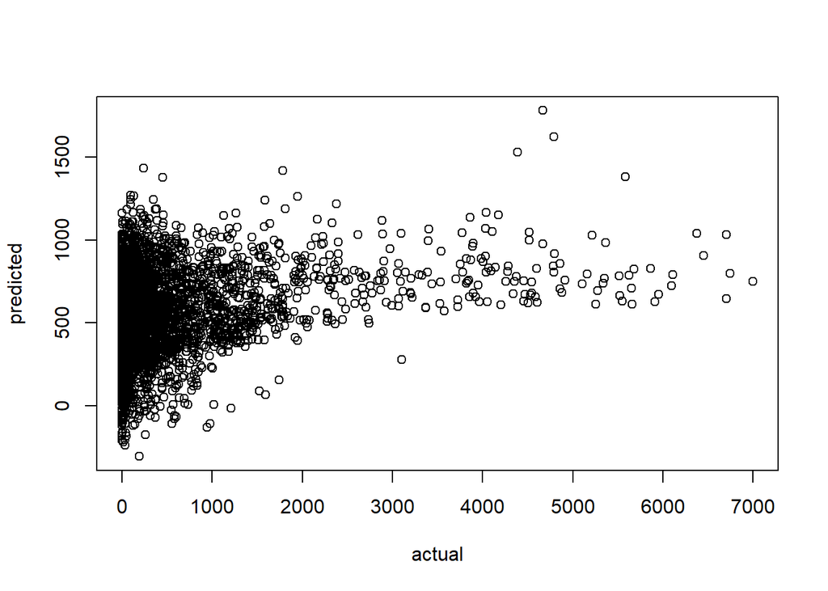

```
## numeric(0)
```

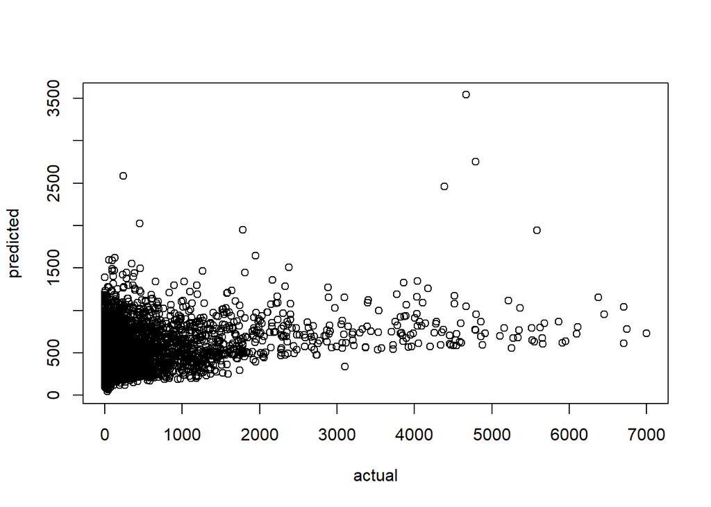

```
## [1] 0.08294384
```

[output not shown]

[output cut: 437 more lines]

[output not shown]

```
##        lower prediction    upper
## 1  358.78111        413 466.4054
## 2  309.83529        357 403.7416
## 3   90.12272        176 262.2683
## 4   78.21369        142 206.5072
## 5  317.77884        372 427.1528
## 6  284.11069        338 391.6543
## 7  332.12141        379 425.3713
## 8  315.33482        386 457.2074
## 9  296.52789        361 425.3907
## 10 216.39419        294 372.2883
```

# Regresión Avanzada

Para la regresión avanzada, vamos a utilizar la fusión de movilidad y covid por provincias que hemos realizado antes del modelo GLM, ya que para el modelo GLM habíamos descartado muchas para mejorar la interpretación. Este dataset esta formado por 22 variables, lo que será suficiente para nuestro modelo de regresión avanzada.

En primer lugar dividiremos nuestro dataset en training y testing. Graficando nuestra variable respuesta, que ahora es las muertes diarias, podemos observar que no hay grupos muy diferenciados. Con esto podemos observar grupos más diferenciados donde estan lo diás que ha habido pocas muertes y aquellos donde ha habido más

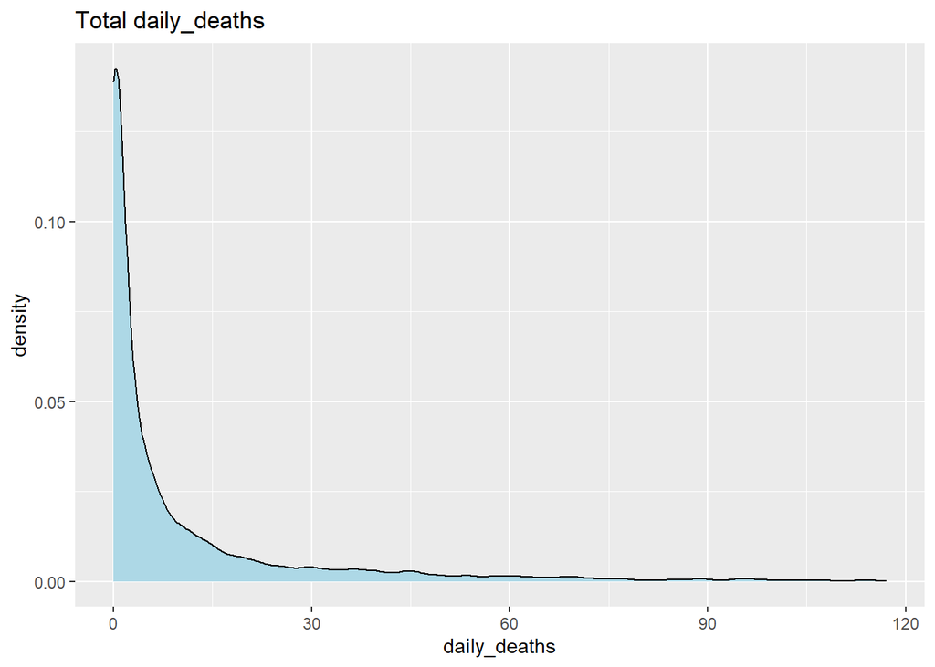

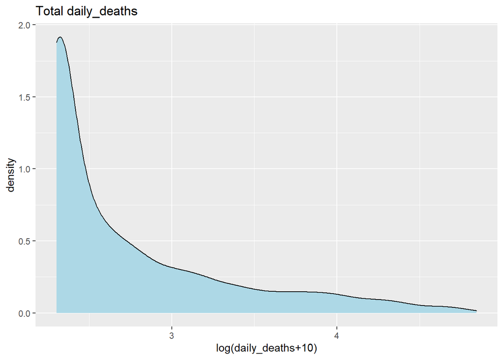

Podemos observar, en el primer gráfico, que no hay relación aparente entre las muertes y los datos de movilidad diarios. Para saber el impacto que puede tener cada una de las variables con la variable respuesta, he creado un segundo gráfico de barras de la correlación de las diferentes variables con la variable respuesta, y las he ordendo de mayor a menos. Podemos observar que muchas de ellas están por encima del 50% de correlación y que prácticamente todas las de movilidad tienen una correlación negativa muy baja

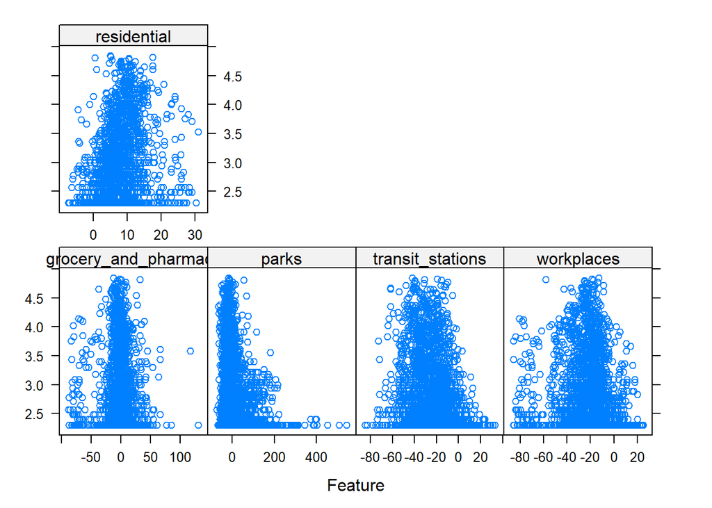

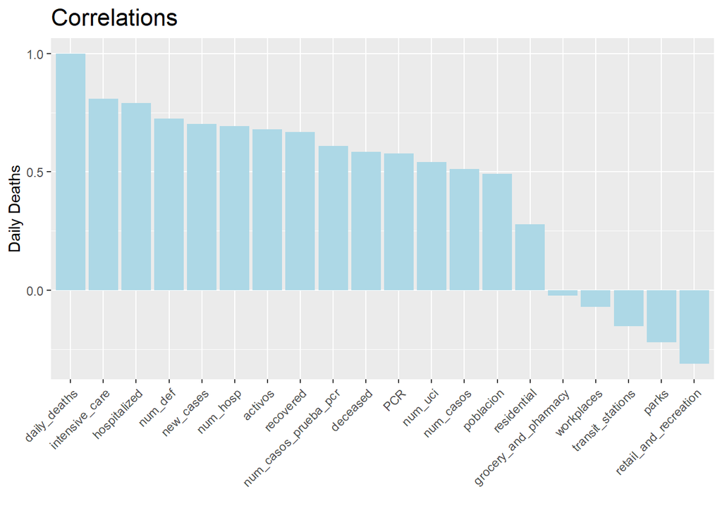

## Métodos de regresión

Antes de empear a entrenar nuestro modelo, es necesario implementar algunos métodos que optimizarán su entrenamiento. Vamos a diseñar en primer lugar una variable que realizará el cross validatión para así entrenar mejor nuestro modelo. El cross validation va a dividir nuestro set de entrenamiento en 5 bloques y va a repetir cada secuencia de entrenamiento 4 veces por bloque. Para que nuetos modelos de regularización nos puedean mejorar los betas, tenemos que introducirle únicamente variables numéricas. Es por eso, que he eliminado todas las posibles variables categóricas del dataset.

### Ridge Regression

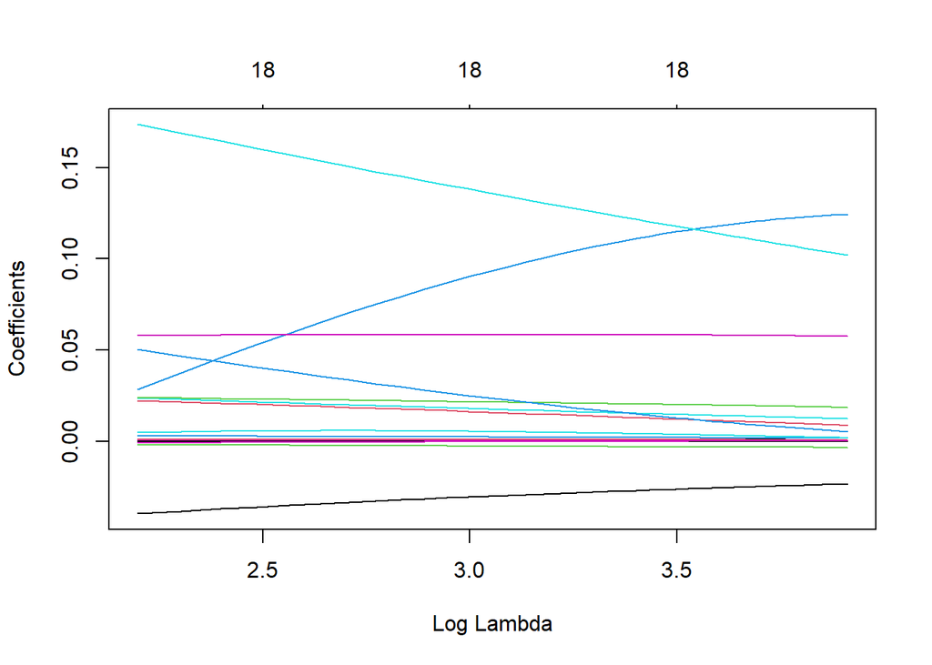

En tercer lugar hemos hecho un cross validation con lambda = 0, para encontrar el mejor lambda. Aquí podemos observar que el mejor lambda para predecir es lambda = 1,43. El segundo lambda es mejor utilizarlo para interpretar y así ver los betas.

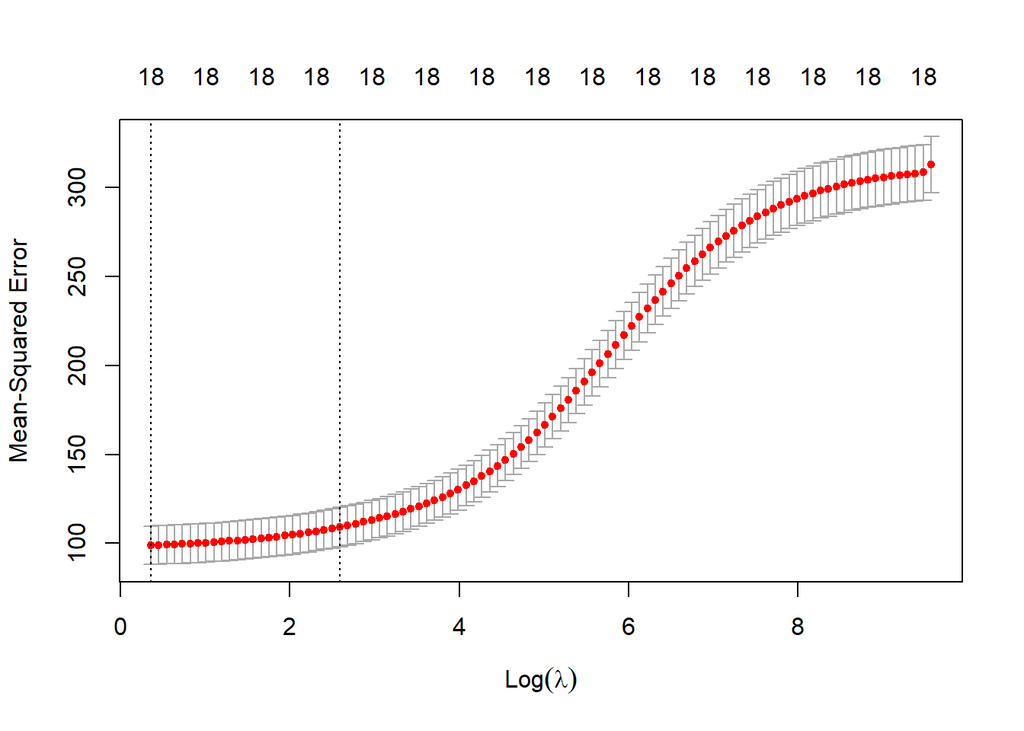

```
## [1] "Lambda para predecir:1.43228891194617"
```

```
## [1] "Lambda para explicar:13.3575743020706"
```

```
##             new_cases                   PCR               activos
##          1.121980e-03          3.194534e-04          1.560950e-04
##          hospitalized        intensive_care              deceased
##          2.862052e-03          2.095689e-02          4.322474e-04
##             recovered  num_casos_prueba_pcr              num_hosp
##          2.145193e-05          1.014258e-03          2.303854e-02
##               num_uci               num_def             num_casos
##          6.183452e-02          1.559565e-01         -3.383157e-04
## retail_and_recreation  grocery_and_pharmacy                 parks
##         -3.462072e-02          1.964509e-02         -2.043631e-03
##      transit_stations            workplaces           residential
##          3.729307e-02          5.896975e-03          5.851925e-02
```

A la hora de predecir tenemos que utilizan nuestro testing set. Podemos observar que las métricas de RMSE y MAE son muy altas indicando que los valores predichos y observados son muy lejanos entre sí. Aun así, para el R-cuadrado nuestro modelo lo ha hecho decentemente.

```
##       RMSE   Rsquared        MAE
## 11.8584330  0.6296705  5.3611317
```

### Regresión de Lasso

La reresión de Lasso a diferencia de la de Ridge, utiliza la norma 1 lo que hace que no haya gradiente que minimice y tenga que acudir a un algoritmo de optimización. En este método a diferencia del de Ridge, te lleva los betas a 0 y selecciona los mejores betas, lo que hace que sea mejor para interpretar.

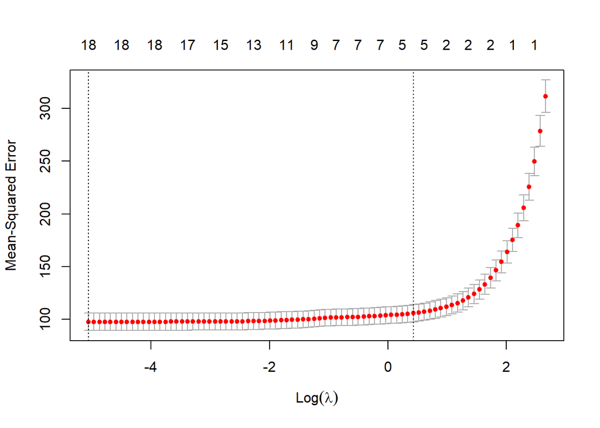

```
## [1] "Lambda para predecir:0.00634592997793075"
```

[output not shown]

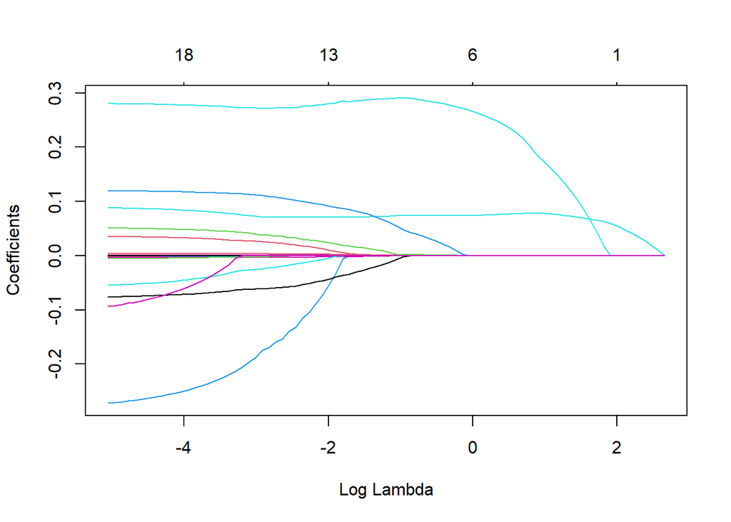

```
##             new_cases                   PCR               activos
##          0.000000e+00          0.000000e+00          1.637967e-05
##          hospitalized        intensive_care              deceased
##          0.000000e+00          7.622887e-02          1.928268e-04
##             recovered  num_casos_prueba_pcr              num_hosp
##          0.000000e+00          1.076710e-04          0.000000e+00
##               num_uci               num_def             num_casos
##          0.000000e+00          2.419379e-01          0.000000e+00
## retail_and_recreation  grocery_and_pharmacy                 parks
##          0.000000e+00          0.000000e+00          0.000000e+00
##      transit_stations            workplaces           residential
##          0.000000e+00          0.000000e+00          0.000000e+00
```

Podemos observar que sigue tienendo un error muy alto en la predicción aunque en las métricas de RMSE y MAE, ha ejecutado mejor que en Ridge Regression.

```
##       RMSE   Rsquared        MAE
## 11.8303049  0.6264397  5.2822428
```

### Elastic Net

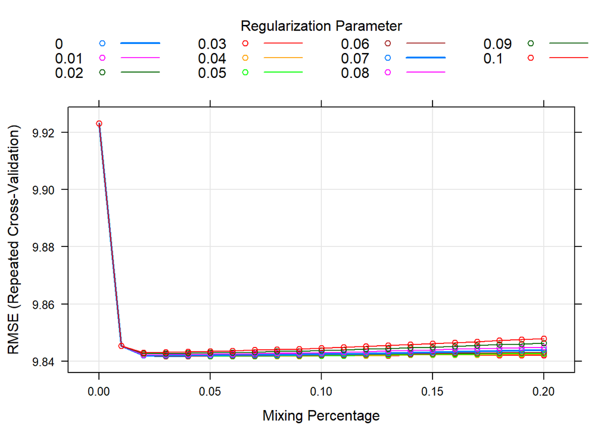

```
##    alpha lambda
## 39  0.03   0.05
```

```
##       RMSE   Rsquared        MAE
## 11.8367984  0.6262461  5.2939202
```

## Métodos de reducción de dimensiones

Los métodos de reducción de dimensión simplifican el número de variables que se utilizan para el modelo. Para ello utilizaremos el PCR y el PLS que son los utilizados en regresión. Ambos utilizan PCA para reducir lo único que PCR utiliza los betas para hacer la regresión . En cambio en PLS le das más peso a la variable que tenga más correlación reemplazando la formula de los PCAs por los betas. En resumen, PCR identifica la dirección de una manera no supervisada, mientras que PLS lo hace de una manera supervisada utilizando ‘y’.

### PCR

Este método, como hemos dicho anteriormente, utiliza PCA para hacer la componentes y luego a través de cross validation elige cuantas componentes utilizar, maximizando la información de las ‘x’. Podemos ver que entre utilizar 5 o 6 componentes vamos a tener prácticamente el mismo error pero entre utilizar 5 u 8 ya cambia bastante.

Las métricas aun así, no son muy buenas empeorando los resultados que habíamos obtenido en el mejor método de regresión.

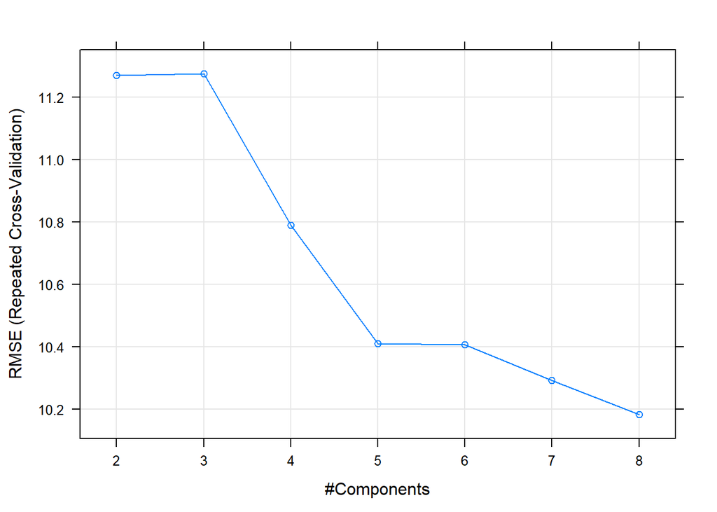

```
##       RMSE   Rsquared        MAE
## 11.8727260  0.6286197  5.5672126
```

### PLS

En este método se da más peso a aquellas variables que predicen mejor observando la variable respuesta, minimizando el error de prediccion de la ‘y’. En el gráfico podemos ver que con PLS probablemente lo mejor seria utilizar 5 o 6 componentes ya que no hay mucha diferencia en el error al utilizar más.

PLS suele predecir mejor que PCR, pero en este caso esta prediciendo peor, si nos fijamos en las métricas.

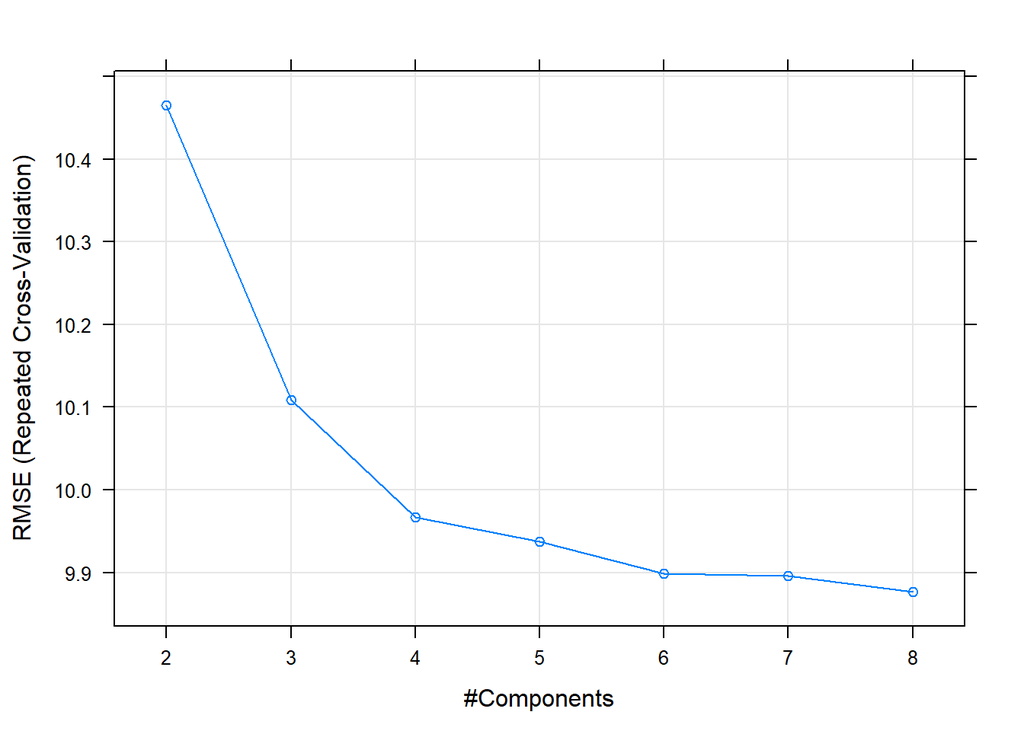

```
##       RMSE   Rsquared        MAE
## 11.9474817  0.6181642  5.3954302
```

## Modelo final

Para el modelo final, únicamente utilizaré Lasso ya que ha sido el método que mejores métricas me ha dado. A través de esté modelo, calcularé los intervalos de confianza de la variable.

Podemos observar que las bandas de los intervalos de confianza son muy anchas y las prediccioness no son nada buenas, prediciendo incluso números negativos, lo que no tiene sentido en este problema ya que las muertes no pueden ser negativas.

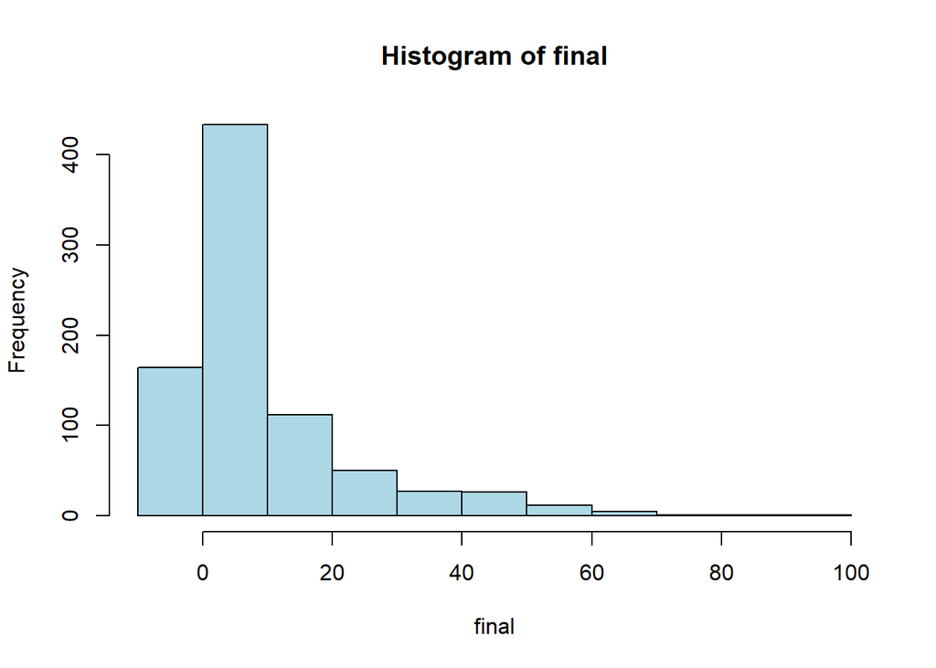

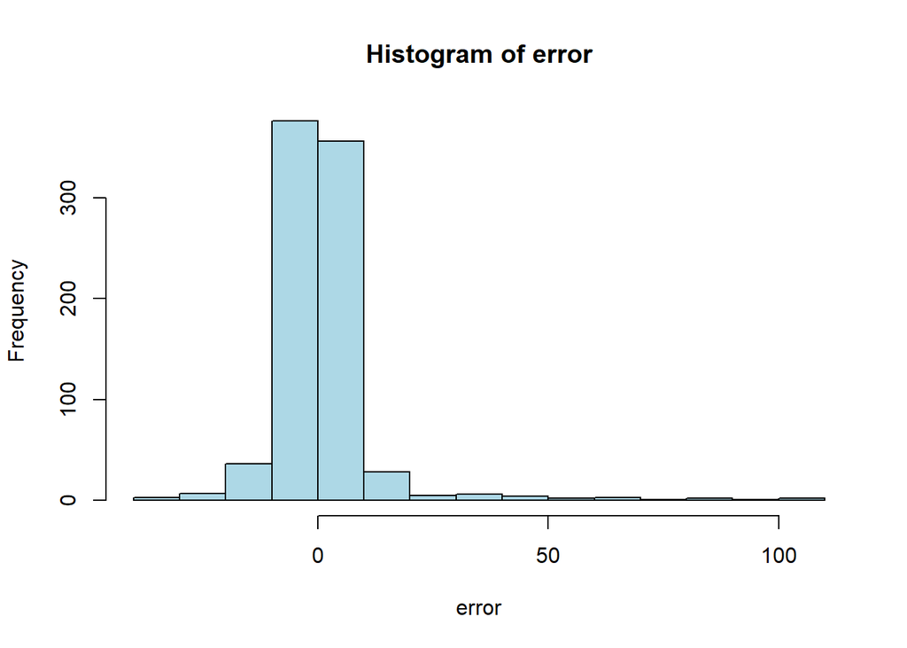

```
##   real        fit       lwr      upr
## 1    0 -2.1448401 -18.56288 14.27320
## 2    1 -1.1429105 -17.56095 15.27513
## 3    0 -2.5109905 -18.92903 13.90705
## 4    1 -0.3920146 -16.81005 16.02602
## 5    0 -0.7589981 -17.17703 15.65904
## 6    1 -0.2486126 -16.66665 16.16942
```

# Conclusiones

A nivel predictivo no podemos conlcuir afirmando nada, ya que las predicciones han sido muy malas. Esto se ha dado principalmente por la calidad de nuestros datos, con un datset que contenía muchos missing values que han tenido que ser imputados de manera manual.

A nivel explicativo no puedo sacar muchas conclusiones ya que muchos de los modelos me daban soluciones muy extrañas como que, a medida que aumentan los test PCR aumentan el número de fallecidos. Esto no podría darse en un entorno realista ya que, a medida que aumentan las pruebas PCR los especialistas deberían tener mas recursos para reducir la incertidumbre y de verdad tratar de una manera específica a aquellos pacientes con Covid. Los únicos datos que han podido tener valor explicativo son los de movilidad, ya que a medida que las personas frecuentaban más las farmacias y supermercados aumenta lo que es bastante significativo ya que a las farmacias acuden personas enfermas que pueden presentar síntomas del virus. Pero en cambio había otras variables de movilidad como la de estaciones de metro, que en un principio las verías muy relevantes en tu modelo y luego no lo han sido. Otras variables como la de movilidad en los parques que te daba también resultados incongruentes como que a medida que aumenta el tránsito en los parques diminuía el número de casos

En conclusión, es muy arriesgado afirmar ciertas teorías sobre recursos y movilidad. Con los resultados obtenidos no podríamos sacar nada en claro para confirmar que el Covid se dió por una falta de recursos y de previsión o incluso por malas decisiones.